# ENVS 193 - HW 5

Riley Zamora

2023-06-06

# Introduction

Sarracenia are a genus of carnivorous plants commonly known as pitcher plants. They are native to North America and are characterized by their pitcher-shaped leaves that trap and digest insects. There are multiple reasons why people may find Sarracenia interesting. For one, they have fascinating ways of catching and eating insect, which makes scientists very interested in studying them. Moreover, they fulfill significant ecological functions as insectivorous plants, aiding in insect regulation and nutrient recycling within their ecosystems. Additionally, Sarracenia’s unique pitcher shape and colors make them popular among plant enthusiasts.  
Predicting individual biomass from morphological, physiological, or taxonomic characteristics provides researchers with valuable insights. It enables them to estimate plant growth and productivity, gain understanding of ecological interactions and responses to environmental changes, and evaluate the impact of plants on ecosystem functioning. Biomass prediction has practical applications in fields like agriculture and forestry, where it aids in decision-making regarding crop yield, and more.  
We will be addressing how some independent variables can predict the total mass of our plant data. We will be checking the assumptions tied to multiple linear regression as well as finding the best predictors for total mass. Our main hypothesis is if our predictor variables are significant in predicting total mass.

# Methods

#### Libraries

These libraries are used throughout the assignment. I emphasize the use of tidyverse.

```r
library(tidyverse)
library(here)
library(janitor)
library(ggeffects)
library(performance)
library(naniar) # or equivalent
library(flextable) # or equivalent
library(car)
library(broom)
# would be nice to have
library(corrplot)
library(AICcmodavg)
library(GGally)
```

#### Import data using here package

Using the `here` package for data reading allows anyone to run this .rmd if they have previously downloaded the dataset .csv file. It grabs the path to the downloaded file from your computer and reads it in.

```r
plant <- read.csv(here("hf109-01-sarracenia.csv")) %>%
  clean_names() %>%
  select(totmass, species, feedlevel, sla, chlorophyll, amass, num_lvs, num_phylls) %>%
  mutate(species = factor(species))
```

## Part A

#### Where the data came from

This data was collected in a “manipulative feeding experiment to test whether morphological and physiological allometric relationships of carnivorous plants when nutrients are not limiting are more similar to allometric relationships of non-carnivorous plants.” The researchers examined a feeding experiment to study the effects of prey availability on the characteristics of carnivorous plants, specifically pitcher plant species. The experiment involved measuring various parameters such as photosynthetic rate, chlorophyll content, growth, plant architecture, and nutrient content of the plants’ leaves. The goal of the sampling methods was to test “… the hypothesis that increased prey availability would stimulate Amass of one or more leaves, increase photosynthetic N- and P-use efficiencies (PNUEN, PNUEP), increase relative biomass allocation to photosynthetically efficient, non-predatory phyllodes rather than pitchers, increase overall plant biomass, and reduce stress-related chlorophyll fluorescence.”

## Part B

#### Organization

For data organization, we start by choosing our response (totmass), and our predictor variables (species, feedlevel, sla, chlorophyll, amass, num_lvs, num_phylls). We then want to make sure that they are easy to call and acess so we clean the names. This removes spaces, adds underscores, and lowercase all characters. Finally we need to make sure that our variables are in the correct format. I mutated species to be a factor, although I belive it might have already been a factor.

## Part C

#### Visualize Missingness

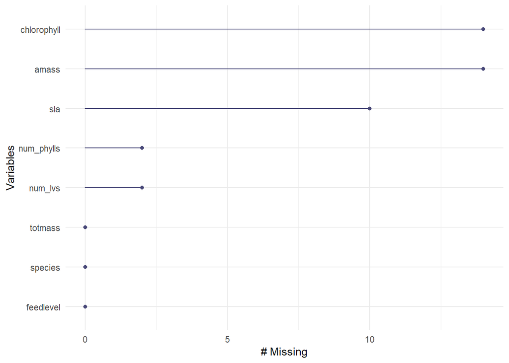

```r
gg_miss_var(plant)
```

In this figure, we can see that chlorophyll, amass, sla, and num_lvs have missing data values. Chlorophyll and amass have over 10 missing, sla has 10 and num_phylls/num_lvs have less than 3 missing values. The rest of the variable have no missing data.

#### Remove NA

```r
# creating a dataset without the missing values
plant_clean <- plant %>%
  drop_na(sla, chlorophyll, amass, num_lvs, num_phylls)
```

## Part D

#### Visualize Correlation

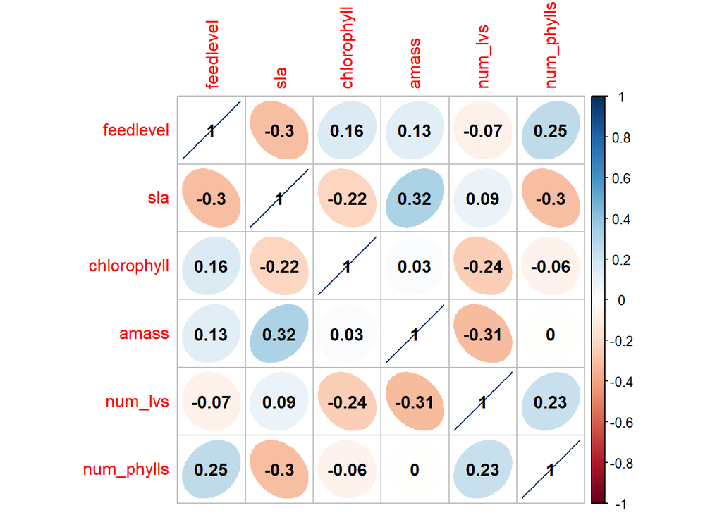

```r
# calc Pearson's r for numerical values
plant_corr <- plant_clean %>%
  select(feedlevel:num_phylls) %>%
  cor(method = "pearson")

# plot correlation values
corrplot(plant_corr,
         method = "ellipse",
         addCoef.col = "black")
```

The correlation figure illustrates the correlation values between various variables. A higher absolute value indicates a stronger correlation between the variables. For instance, the variables sla and amass exhibit the highest positive correlation, with a correlation coefficient of 0.32. Conversely, num_lvs and amass exhibit the strongest negative correlation, with a correlation coefficient of -0.31.

## Part E

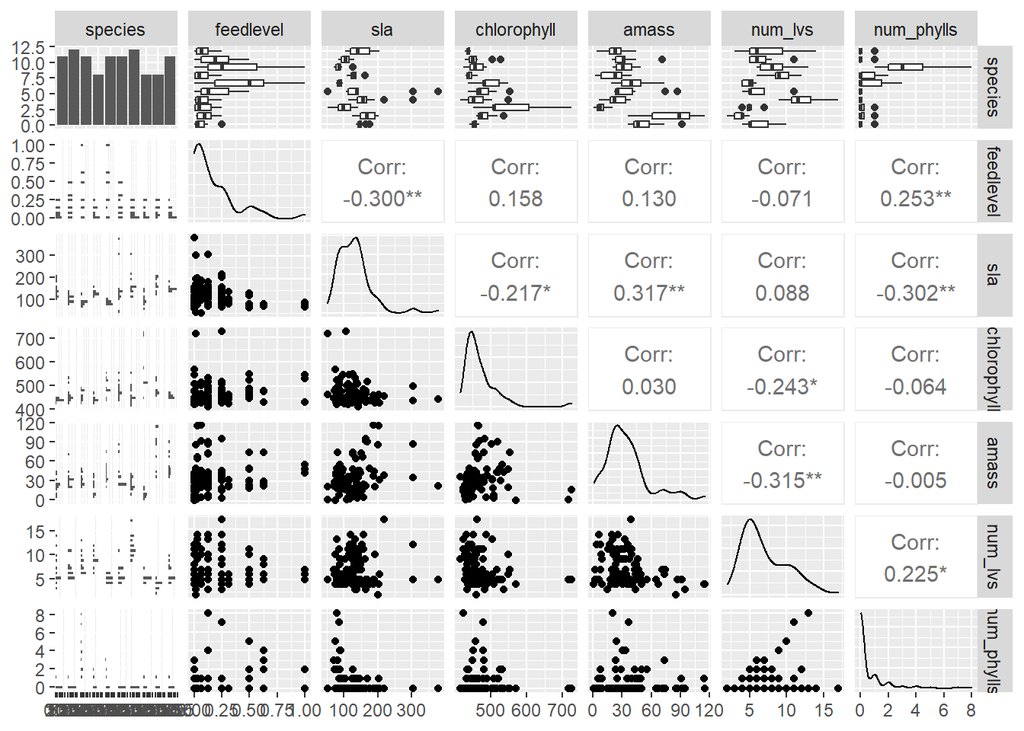

```r
plant_clean %>%
  select(species:num_phylls) %>%
  ggpairs()
```

## Part F

#### Fitting Models

```r
null <- lm(totmass ~ 1, data = plant_clean) # just beta_0
full <- lm(totmass ~ species + feedlevel + # all predictors
             sla + chlorophyll + amass +
             num_lvs + num_phylls,
           data = plant_clean)
```

The null model only includes the intercept and response, `totmass`. The full model has all predictors in the dataset and the response as `totmass`.

## Part G

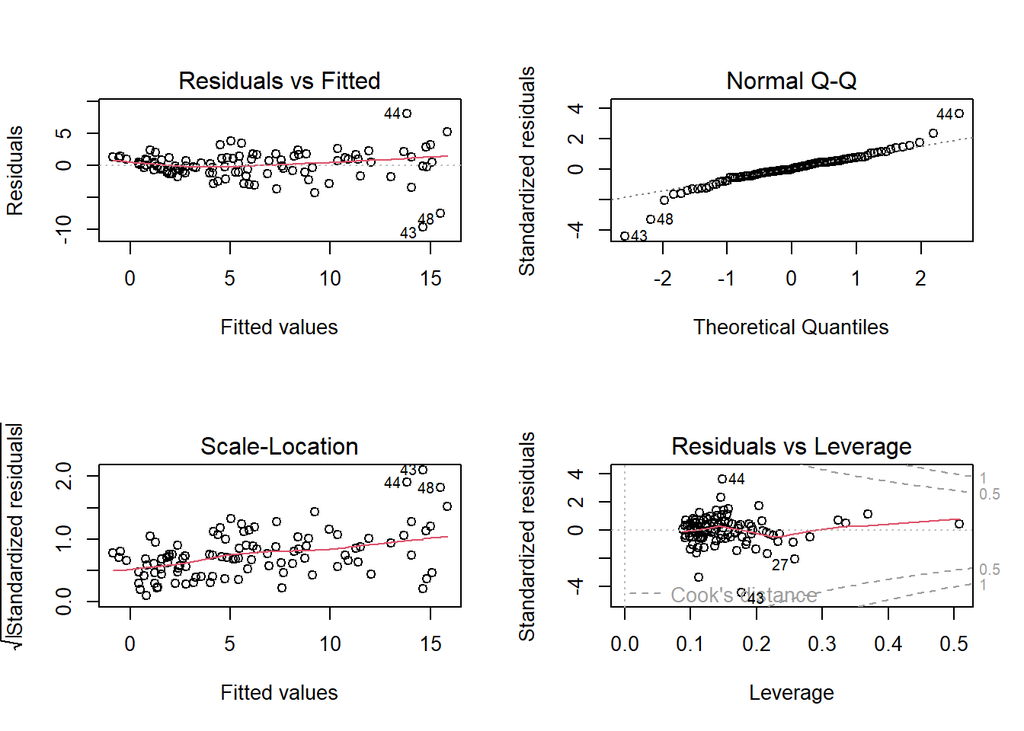

```r
par(mfrow = c(2, 2)) # facet the plots
plot(full) # will show diagnostic plots
```

```r
# statistical diagnostics
check_normality(full)
```

[output not shown]

We get that “Non-normality of residuals detected (p < .001).” which means that we have to perform some transformations.

```r
check_heteroscedasticity(full)
```

[output not shown]

we get that “Heteroscedasticity (non-constant error variance) detected (p < .001).” more reason to perform a log transformation.

## Part H

#### Fitting Log transform models

I am going to perform a log transformation to the data to try and achieve normality and constant variance.

```r
# creating log transformed models
lognull <- lm(log(totmass) ~ 1, data = plant_clean)
logfull <- lm(log(totmass) ~ species + feedlevel +
                 sla + chlorophyll + amass + num_lvs +
                 num_phylls,
               data = plant_clean)
```

#### diagnostic checking

```r
check_normality(logfull)
```

```
## OK: residuals appear as normally distributed (p = 0.107).
```

Our data is normal after the log transofrm.

```r
check_heteroscedasticity(logfull)
```

```
## OK: Error variance appears to be homoscedastic (p = 0.071).
```

We have constant variance after the log transform! We will continue using the log model.

## Part I

#### Model construction using stepwise selection

Step wise selection is a way to select a model by testing the AIC of different predictor variations. Here we are using backward selection and starting with the full log-model.

```r
step(logfull, direction = 'backward')
```

```
## Start:  AIC=-167.56
## log(totmass) ~ species + feedlevel + sla + chlorophyll + amass +
##     num_lvs + num_phylls
##
##               Df Sum of Sq    RSS      AIC
## - num_phylls   1     0.100 14.939 -168.868
## - amass        1     0.104 14.943 -168.837
## <none>                     14.839 -167.559
## - feedlevel    1     0.698 15.537 -164.827
## - sla          1     0.788 15.627 -164.233
## - chlorophyll  1     2.300 17.139 -154.715
## - num_lvs      1     2.859 17.698 -151.411
## - species      9    57.156 71.995  -22.888
##
## Step:  AIC=-168.87
## log(totmass) ~ species + feedlevel + sla + chlorophyll + amass +
##     num_lvs
##
##               Df Sum of Sq    RSS      AIC
## - amass        1     0.087 15.026 -170.269
## <none>                     14.939 -168.868
## - feedlevel    1     0.659 15.598 -166.422
## - sla          1     0.761 15.700 -165.750
## - chlorophyll  1     2.365 17.304 -155.732
## - num_lvs      1     2.921 17.860 -152.476
## - species      9    60.796 75.735  -19.672
##
## Step:  AIC=-170.27
## log(totmass) ~ species + feedlevel + sla + chlorophyll + num_lvs
##
##               Df Sum of Sq    RSS     AIC
## <none>                     15.026 -170.27
## - feedlevel    1     0.596 15.622 -168.26
## - sla          1     0.676 15.702 -167.74
## - chlorophyll  1     2.687 17.713 -155.32
## - num_lvs      1     2.866 17.893 -154.28
## - species      9    61.560 76.586  -20.52
```

```
##
## Call:
## lm(formula = log(totmass) ~ species + feedlevel + sla + chlorophyll +
##     num_lvs, data = plant_clean)
##
## Coefficients:
##        (Intercept)        speciesalata        speciesflava      speciesjonesii
##          -1.391293            1.137098            1.303336            0.318323
## speciesleucophylla        speciesminor   speciespsittacina     speciespurpurea
##           1.696525            0.397390           -1.613985           -0.434552
##       speciesrosea        speciesrubra           feedlevel                 sla
##          -0.866787            0.928795           -0.430123           -0.002127
##        chlorophyll             num_lvs
##           0.004603            0.083852
```

#### Running diagnostics on the models proposed

model 1 is our full log model and we have already ran diagnostics on that model so I am going to skip to the next model.

#### Model 2

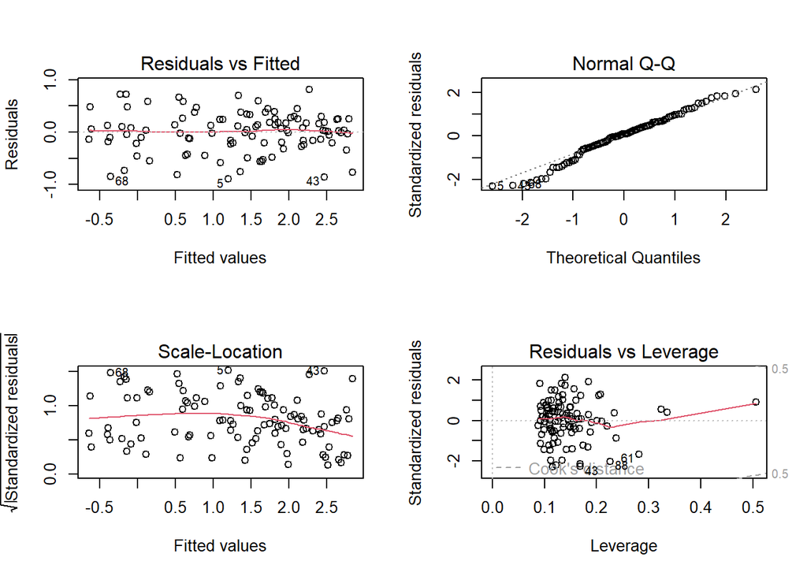

```r
model2 <- lm(log(totmass) ~ species + feedlevel + sla + chlorophyll +
               amass + num_lvs, data = plant_clean)
# plotting model2 diagnostics
par(mfrow = c(2, 2))
plot(model2)
```

```r
check_normality(model2)
```

```
## OK: residuals appear as normally distributed (p = 0.100).
```

```r
check_heteroscedasticity(model2)
```

```
## OK: Error variance appears to be homoscedastic (p = 0.086).
```

We know from backward stepwise section that this is not our best performing model. However, it passes our diagnostic checks!

#### Model 3

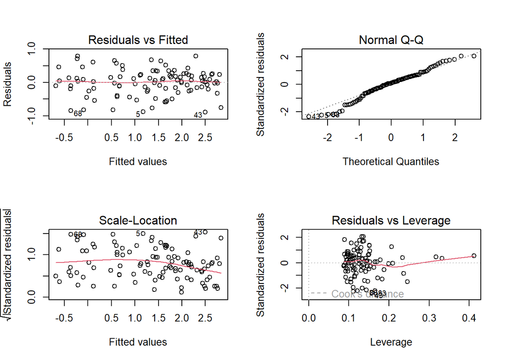

```r
model3 <- lm(log(totmass) ~ species + feedlevel + sla +
               chlorophyll + num_lvs, data = plant_clean)

# plotting model3 diagnostics
par(mfrow = c(2, 2))
plot(model3)
```

```r
check_normality(model3)
```

```
## OK: residuals appear as normally distributed (p = 0.062).
```

```r
check_heteroscedasticity(model3)
```

```
## OK: Error variance appears to be homoscedastic (p = 0.067).
```

Here we can see that model3 still passes our diagnostic checks, and from stepwise AIC we know that this model out performs model 2. We know that using backwards stepwise selection with the `step()` function automatically stops when the model AIC increases. Thus model 3 is the best choice for predicting with.

## Part K

#### Model Comparison

To perform some model comparison, we will create a table consisting of all models AIC.

```r
MuMIn::AICc(full, null, logfull, lognull, model2, model3) # this shows the aic for every model I have worked with so far
```

```
##         df     AICc
## full    17 497.3964
## null     2 630.4028
## logfull 17 133.9424
## lognull  2 306.0028
## model2  16 131.7593
## model3  15 129.5498
```

Again, we see that model3 has the lowest AIC and is the most simple model. This is ideal for predicting as a more complicated model can have adverse affects on the outcome of our predictions.

# Results

## Part A

Model 3 consists of the predictor variables species, feedlevel, sla, chlorophyll, num_lvs and a response variable log(totmass). I chose this model using the stat function `step()` with direction set to backwards. This automatically checks the AIC and stops when it has reached the best model. I double checked the diagnostics for each model that the step function went thorough to be extra careful.

#### Summary of model results

```r
table1 <- tidy(model3, conf.int = TRUE, exponentiate = TRUE) %>%
  # make it into a flextable
  flextable() %>%
  # fit it to the viewer
  autofit()

table1
```

| term | estimate | std.error | statistic | p.value | conf.low | conf.high |
| --- | --- | --- | --- | --- | --- | --- |
| (Intercept) | 0.2487535 | 0.585388789 | -2.376699 | 0.019611401006898569 | 0.07773513 | 0.7960145 |
| speciesalata | 3.1177086 | 0.179533417 | 6.333630 | 0.000000009533443427 | 2.18227786 | 4.4541105 |
| speciesflava | 3.6815578 | 0.196108146 | 6.646006 | 0.000000002335496696 | 2.49346488 | 5.4357564 |
| speciesjonesii | 1.3748207 | 0.195367931 | 1.629353 | 0.106772894004590987 | 0.93251636 | 2.0269156 |
| speciesleucophylla | 5.4549604 | 0.212726581 | 7.975145 | 0.000000000004885733 | 3.57456029 | 8.3245463 |
| speciesminor | 1.4879363 | 0.185606930 | 2.141031 | 0.035005049074453343 | 1.02900584 | 2.1515471 |
| speciespsittacina | 0.1990927 | 0.200970367 | -8.030959 | 0.000000000003753586 | 0.13354609 | 0.2968106 |
| speciespurpurea | 0.6475548 | 0.243678551 | -1.783299 | 0.077946618166472151 | 0.39902312 | 1.0508846 |
| speciesrosea | 0.4202997 | 0.213092762 | -4.067653 | 0.000102425514875563 | 0.27521626 | 0.6418655 |
| speciesrubra | 2.5314569 | 0.177514843 | 5.232210 | 0.000001103697661969 | 1.77904515 | 3.6020863 |
| feedlevel | 0.6504289 | 0.228915557 | -1.878960 | 0.063522841185113463 | 0.41272508 | 1.0250353 |
| sla | 0.9978755 | 0.001062740 | -2.001167 | 0.048420790786492210 | 0.99577061 | 0.9999849 |
| chlorophyll | 1.0046140 | 0.001153958 | 3.989185 | 0.000135789498714607 | 1.00231313 | 1.0069201 |
| num_lvs | 1.0874684 | 0.020350265 | 4.120456 | 0.000084568149269557 | 1.04437314 | 1.1323419 |

## Part B

By fitting this linear regression model, we can estimate the relationship between the response variable (log of totmass) and the predictors (species, feedlevel, sla, chlorophyll, and num_lvs). The coefficients obtained from the model can provide information about the direction and magnitude of the relationships. Additionally, we can assess the overall goodness of fit of the model and evaluate the significance of the predictors through statistical tests like the AIC.

## Part C

#### Visualize model predictions

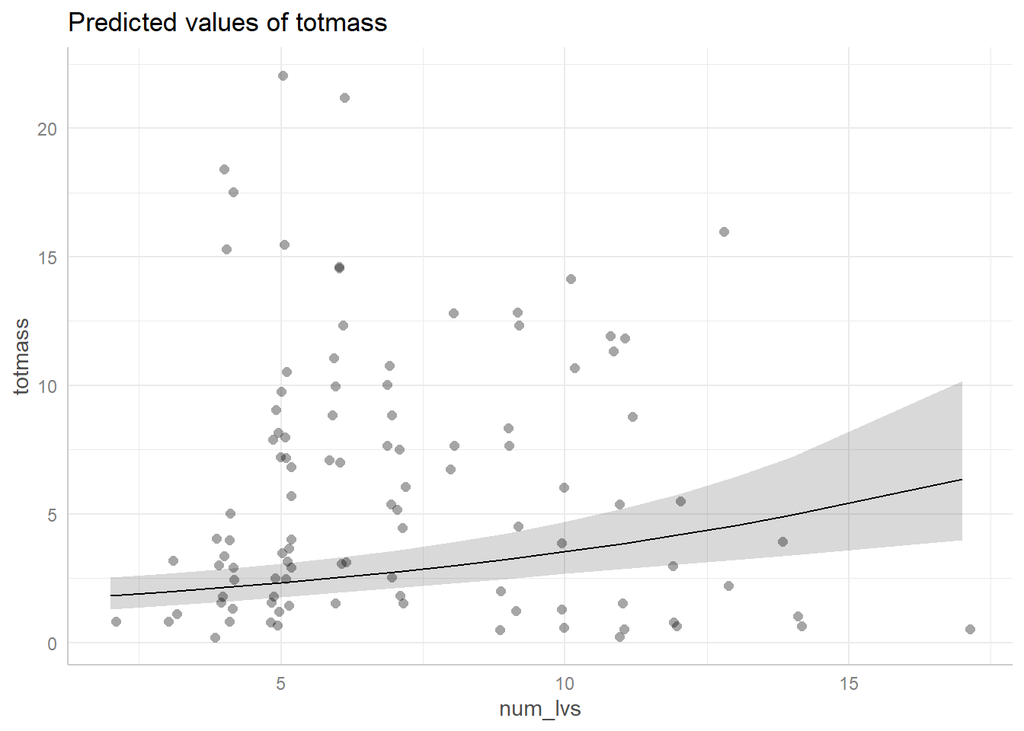

```r
# Calculate predictions based on model3  for the variable 'species'
model_pred <- ggpredict(model3, terms = "num_lvs", back.transform = TRUE)

# Plot the predicted values from model_pred along with the original data points
plot(model_pred, add.data = TRUE)
```

Here we can see that for the predicted data points (black line), that as num levels increases, so does the total mass. It is noteworthy that as we get higher into our num levels our prediction interval get much wider. This means that we have less certainty for our predictions as num levels increases. Intuitively this makes sense because, looking at our actual data, there is less information around higher levels. We can see where our model predicts and where the actual values sit but this is a part of linear regression and finding an estimation for the data.

## Part D

Biologically, this model means that we can predict the total mass of plants from different independent variables. In our case with model3 we have chosen what seems to be the best combination of predictor variables. This is exciting because it allows us to, in a sense, predict future outcomes of plant data (or any data we use).

# Bibliography

- Check out my [github!](https://github.com/rileyjzamo/ENVS-193DS_homework-05_Zamora-Riley/tree/main)
- Find this data [at this website](https://portal.edirepository.org/nis/mapbrowse?packageid=knb-lter-hfr.109.18)